# Multiple Logistic Regression

Jim Greene

2018-04-13

```r
datatable(subset(GSS2012[, c(647, 38, 802)], wordj == 1 | wordj == 0))
```

|  | sex | age | wordj |
| --- | --- | --- | --- |
| 1 | 1 | 22 | 1 |
| 4 | 2 | 49 | 0 |
| 5 | 2 | 70 | 0 |
| 6 | 2 | 50 | 0 |
| 7 | 2 | 35 | 0 |
| 9 | 2 | 28 | 0 |
| 11 | 1 | 55 | 0 |
| 12 | 2 | 36 | 0 |
| 15 | 1 | 52 | 0 |
| 18 | 2 | 47 | 0 |

[output cut: 1196 more lines]

My intention is to create a logistic regression model for the probability that someone will give the correct answer:
$$P(Y_i = 1|\, x_{i1},x_{i2}) = \frac{e^{β_0 + β_1X_{i1} + β_2X_{i2} + β_3X_{i1} X_{i2} }}{1+e^{β_0 + β_1X_{i1} + β_2X_{i2} + β_3X_{i1} X_{i2} }} = \pi_i,\text{ } x_{i1}=age, x_{i2}=sex$$

I will test for all of these:
$$H_0:β_0=0$$

$$H_a:β_0≠0$$

$$H_0:β_1=0$$

$$H_a:β_1≠0$$
$$H_0:β_2=0$$

$$H_a:β_2≠0$$
$$H_0:β_3=0$$

$$H_a:β_3≠0$$
Level of significance:
$$\alpha = 0.05$$

```r
GSS2012.glm <- glm(wordj==1 ~ age + as.factor(sex) + age:as.factor(sex), data=GSS2012, family=binomial)
pander(summary(GSS2012.glm))
```

|  | Estimate | Std. Error | z value | Pr(>\|z\|) |
| --- | --- | --- | --- | --- |
| **(Intercept)** | -0.8229 | 0.2543 | -3.237 | 0.00121 |
| **age** | -0.01685 | 0.005356 | -3.146 | 0.001658 |
| **as.factor(sex)2** | -0.7304 | 0.3524 | -2.073 | 0.0382 |
| **age:as.factor(sex)2** | 0.01292 | 0.007175 | 1.8 | 0.0718 |

(Dispersion parameter for binomial family taken to be 1 )

| Null deviance: | 1720 on 1973 degrees of freedom |
| --- | --- |
| Residual deviance: | 1707 on 1970 degrees of freedom |

I am using a Hosmer-Lemeshow Goodness of Fit Test to check he assumptions because there are no excessively repeated values.

```r
pander(hoslem.test(GSS2012.glm$y, GSS2012.glm$fitted))
```

Hosmer and Lemeshow goodness of fit (GOF) test: `GSS2012.glm$y, GSS2012.glm$fitted`

| Test statistic | df | P value |
| --- | --- | --- |
| 4.04 | 8 | 0.8535 |

The significant values are the intercept ($\beta_0$), the slope from the age factor ($\beta_1$), and the change in intercept for females ($\beta_2$).

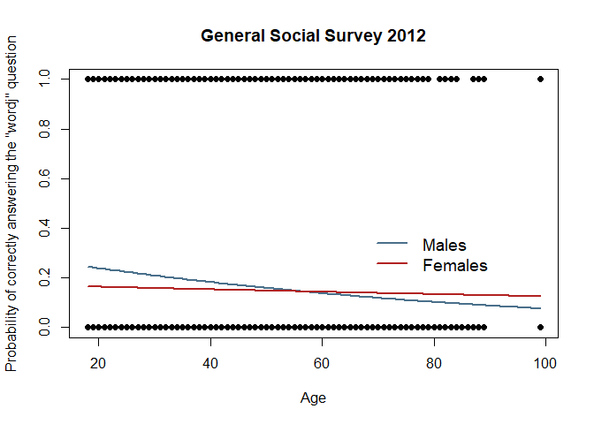

```r
GC <- GSS2012.glm$coefficients
plot(wordj==1 ~ age, data=GSS2012, pch=16, main="General Social Survey 2012", ylab="Probability of correctly answering the \"wordj\" question", xlab="Age")
curve(exp(GC[1]+GC[2]*x)/(1+exp(GC[1]+GC[2]*x)), add=TRUE, col='skyblue4', lwd=2)
curve(exp(GC[1]+GC[3]+(GC[2]+GC[4])*x)/(1+exp(GC[1]+GC[3]+(GC[2]+GC[4])*x)), add=TRUE, col='firebrick', lwd=2)
legend(67, .42, legend=c("Males", "Females"), col=c("skyblue4", "firebrick"), lty=1:1, cex=1.2, box.lty=0, lwd=2)
```

In the plot above, the lines intersect at about age 56 1/2. The p-value for the difference in slopes is not significant enough so I will assume that there is no real difference in the slopes and the observed intersection is not meaningful. What I can confidently say is that males and females both perform slightly worse with age and this is the model that includes the significant values. This model includes the significant $\beta$ values:
$$P(Y_i = 1|\, x_{i1},x_{i2}) = \frac{e^{-0.8229 - 0.01685X_{i1} - 0.7304X_{i2} }}{1+e^{-0.8229 - 0.01685X_{i1} - 0.7304X_{i2} }} = \pi_i,\text{ } x_{i1}=age, x_{i2}=sex$$
Plugging in a gender and age produces the probability.

The odds of answering correctly for each age is 98.3% ($e^{- 0.01685}$) of the odds of the previous age.

The other significant value is the change in intercept. Females have 52% ($1-e^{- 0.7304}$) lower odds of answering correctly than males.